# SVM

Marcin Mazurek

2017-11-22

# Suppport Vector Machines

Maszyna wektorów nośnych / maszyna wektorów podpierających

## Podstawowe pojęcia z geometrii analitycznej

Odległość punktu $M=(x_0, y_0)$ od prostej $l$ danej równaniem w postaci ogólnej:

$l: Ax + By + C = 0$

wyraża się wzorem:

$d(M,l) = \frac{|Ax_0 + By_0 + C|}{\sqrt{A^2+B^2}}$

Moduł wektora (długość wektora, norma):

$\mathbf{u}=[u_1, u_2]$ $u=\sqrt{u_1^2 + u_2^2}$

ogólnie:

$||\mathbf{u}||=\sqrt{u_1^2 + u_2^2 +\cdots + u_p^2}$

## Hierpłaszczyzna rozdzielająca

Rozważmy zadanie wyznaczenia “marginesów” ograniczonych dwiema równoległymi hiperpłaszczyznami, we wnętrzu których nie leży ani jeden element próby uczącej:

$x_1, \cdots, x_n \in R^p$

z przypisanymi etykietami klas:

$y_1, \cdots, y_n \in \{-1,1\}$

Zdefiniujmy parametry hiperpłaszczyzny: $\mathbf{w}=[w_1, w_2, \cdots, w_p]$

$\mathbf{w}^T \mathbf{x} +b \geq 1$ gdy $y_i=1$

oraz

$\mathbf{w}^T\mathbf{x} +b \leq -1$ gdy $y_i=-1$

$H_1$ oraz $H_2$ - hiperpłaszczyzny:

$H_1: \mathbf{w}^T\mathbf{x} +b = 1$

$H_2: \mathbf{w}^T\mathbf{x} +b = -1$

Punkty na hiperpłaszczyznach $H_1$ oraz $H_2$ są końcami wektorów podpierających.

Płaszczyzna rozdzielająca $H_0$ leżąca pomiędzy:

$H_0: \mathbf{w}^T\mathbf{x} +b = 0$

Odległości:

$d_+$ najmniejsza odległość od hiperpłaszczyzny rozdzielającej $H_0$ do punktu Pozytywnego (klasa y=1)

$d_-$ najmniejsza odległość od hiperpłaszczyzny rozdzielającej $H_0$ do punktu Negatywnego (klasa y=-1)

Szerokość marginesu $d= d_+ + d_-$

Odległość hiperpłaszczyzn $H_0$ oraz $H_1$:

$\frac{|\mathbf{w}^T\mathbf{x} +b|}{||\mathbf{w}||}=\frac{1}{||\mathbf{w}||}$

a całkowita odległość:

$d= \frac{2}{||\mathbf{w}||}$

### Zadanie optymalizacji

Aby zmaksymalizować szerokość marginesu, należy zminimalizować $||\mathbf{w}|| \to min$

przy ograniczeniach:

$\mathbf{w}^T \mathbf{x} +b \geq 1$ gdy $y_i=1$

$\mathbf{w}^T\mathbf{x} +b \leq -1$ gdy $y_i=-1$,

które można zapisać :

$y_i ( \mathbf{w}^T {x_i} +b) \geq 1$ dla $i=1 \cdots n$

Hiperpłaszczyzna rozdzielająca: które punkty należy uwzględnić ? - wszystkie (regresja liniowa, sieci neuronowe) - tylko “kłopotliwe”, leżące blisko granicy decyzyjnej : SVM

W rzeczywistości minimalizujemy: $\frac{||\mathbf{w}||^2}{2}$

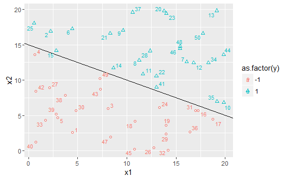

```r
library(ggplot2)
library(ggrepel)
x1<-runif(50)*20
x2<-runif(50)*20
y<- ifelse( (x1 + 2*x2-30 > 0 ), 1, -1)
beta<-c(1,2,-30)
y<- as.factor(ifelse( (x1 + 2*x2-30 > 0 ), 1, -1))
df<-data.frame(x1,x2,y)
df$id<- as.numeric(row.names(df))
p<- ggplot(df, aes(x=x1))+geom_point(aes( y=x2,shape=as.factor(y) ,color=as.factor(y)))  +scale_shape_manual(values=c(1,2)) + geom_abline(intercept=15, slope=-0.5) + geom_text_repel(aes(y=x2,label=id,color=as.factor(y)),size=3)
p
```

## Klasy separowalne liniowo

```r
library(e1071)
m <- svm(y~x1+x2, df, kernel="linear",cost=100000, type="nu-classification", nu=0.04)
summary(m)
```

```
Call:
svm(formula = y ~ x1 + x2, data = df, kernel = "linear",
    cost = 1e+05, type = "nu-classification", nu = 0.04)


Parameters:
   SVM-Type:  nu-classification
 SVM-Kernel:  linear
      gamma:  0.5
         nu:  0.04

Number of Support Vectors:  3

 ( 2 1 )


Number of Classes:  2

Levels:
 -1 1
```

```r
#indeksy punktow (wektory podpierajace)
#index of resulting support vectors in the data matrix
m$index
```

```
[1]  4 16 41
```

```r
#negative intercept
m$rho
```

```
[1] 0.2708138
```

```r
#the corresponding coefficients times the training labels
m$coefs
```

```
          [,1]
[1,]  14.84768
[2,]  37.06645
[3,] -51.91412
```

```r
svm<-df[m$index,]
svm_pos<-svm[svm$y==1,]
svm_pos
```

|  | x1 | x2 | y | id |
| --- | --- | --- | --- | --- |
| 41 | 13.02656 | 8.967422 | 1 | 41 |

```r
svm_neg<-svm[svm$y==-1,]
head(svm_neg)
```

|  | x1 | x2 | y | id |
| --- | --- | --- | --- | --- |
| 4 | 0.6308694 | 13.607623 | -1 | 4 |
| 16 | 17.2536116 | 5.654632 | -1 | 16 |

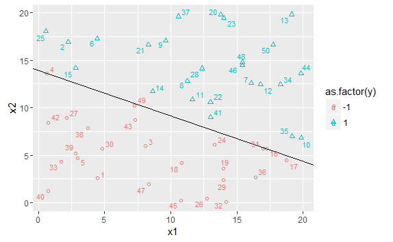

```r
## rownanie pierwszej prostej
if (nrow(svm_pos) > nrow(svm_neg)) {
  idxs<-as.vector(svm_pos[,4])
  idx<-svm_neg[1,4]
} else {
  idxs<-as.vector(svm_neg[,4])
  idx<-svm_pos[1,4]
}
regr<-lm(x2~x1, df[idxs,])
coef<-coefficients(regr)
beta0 <-coef[1]
beta1 <-coef[2]
ggplot(df, aes(x=x1)) +
   geom_point(aes( y=x2,shape=as.factor(y) ,color=as.factor(y)))  +
   scale_shape_manual(values=c(1,2)) +
   geom_abline(intercept=beta0, slope=beta1)  +
   geom_text_repel(aes(y=x2,label=id,color=as.factor(y)),size=3)
```

```r
#rownanie drugiej prostej
df[idx,]
```

|  | x1 | x2 | y | id |
| --- | --- | --- | --- | --- |
| 41 | 13.02656 | 8.967422 | 1 | 41 |

```r
beta02 <- df[idx,2] - beta1*df[idx, 1]
beta0
```

```
(Intercept)
   13.90946
```

```r
beta02
```

```
      x1
15.19985
```

```r
beta1
```

```
        x1
-0.4784404
```

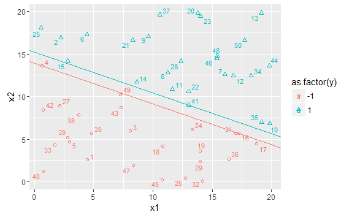

```r
ggplot(df, aes(x=x1))+geom_point(aes( y=x2,shape=as.factor(y) ,color=as.factor(y)))  + scale_shape_manual(values=c(1,2)) +  geom_abline(intercept=beta02, slope=beta1, color="#00BFC4") +  geom_text_repel(aes(y=x2,label=id,color=as.factor(y)),size=3) +  geom_abline(intercept=beta0, slope=beta1, color="#F8766D")
```

## Klasy liniowo nieseparowalne

Jeżeli nie ma płaszczyzny rozdzielającej, przyjmujemy, że część punktów może się znaleźć “po drugiej stronie”, jednak wiąże się to z pewną karą $\xi$ przypisaną dla takiego punktu. Do funkcji kryterium wprowadzona jest wówczas funkcja kary:

$\frac{||\mathbf{w}||^2}{2} + C*\sum_{i=1}^{n}\xi_i$

a ograniczenia przyjmują postać:

$y_i ( \mathbf{w}^T {x_i}+b) \geq 1 -\xi_i$ dla $i=1 \cdots n$

$\xi_i \geq 0$ dla $i=1 \cdots n$

## Nieliniowe granice klas

Klasyfikator z liniowym rozgraniczeniem klas może być przedstawiony w postaci iloczynu skalarnego:

$f(x)=\beta_{0} + \sum_{i=1}^{n}\alpha_{i} \langle x, x_{i} \rangle$ , gdzie

$\langle x_{i}, x_{k} \rangle$ oznacza iloczyn skalarny wektorów:

$$\langle x_{i}, x_{k} \rangle = \sum_{j=1}^{p} x_{i,j}x_{k,i}$$
Współczynniki $\alpha_{i}$ przyjmują niezerowe wartości tylko dla wektorów nośnych , a więc jeżeli przez $\mathbf{SV}$ oznaczymy zbiór indeksów odpowiadających wektorom nośnym to:

$$f(x)=\beta_{0} + \sum_{i \in \mathbf{SV} }\alpha_{i} \langle x, x_{i} \rangle$$
Jeżeli iloczyn skalarny dwóch wektorów uogólnimy do funkcji K : $K(x_{i}, x_{k})$ , zwanej jądrem (kernel), która określa podobieństwo dwóch obserwacji:

$$f(x)=\beta_{0} + \sum_{i \in \mathbf{SV} } \alpha_{i} K( x, x_{i})$$

### Kernels

#### Polynomial kernel

$$K(x_{i},x_{k}) = (1 + \sum_{j=1}^{p} x_{i,j} x_{k,j})^d$$

#### Radial kernel

$$K(x_{i},x_{k}) = exp(-\gamma \sum_{j=1}^{p}(x_{i,j} – x_{k,j})^2 )$$

```r
require(e1071)
require(ElemStatLearn)
library(ggplot2)
#Loading the data
attach(mixture.example)
```

[output not shown]

```r
dataset<-mixture.example
df<-data.frame("x1"=dataset$x[,1], "x2"=dataset$x[,2], "y"=dataset$y)
head(df)
```

|  | x1 | x2 | y |
| --- | --- | --- | --- |
| 1 | 2.52609297 | 0.3210504 | 0 |
| 2 | 0.36695447 | 0.0314621 | 0 |
| 3 | 0.76821908 | 0.7174862 | 0 |
| 4 | 0.69343568 | 0.7771940 | 0 |
| 5 | -0.01983662 | 0.8672537 | 0 |
| 6 | 2.19654493 | -1.0230141 | 0 |

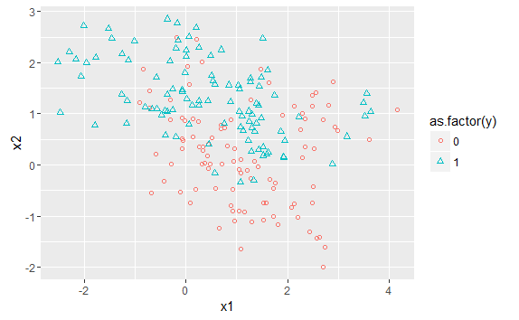

```r
p<- ggplot(df, aes(x=x1))+geom_point(aes( y=x2,shape=as.factor(y) ,color=as.factor(y)))  +scale_shape_manual(values=c(1,2)) + geom_abline(intercept=15, slope=-0.5)
p
```

```r
#
```

```r
radial.svm=svm(factor(y) ~ .,data=df,kernel="radial",cost=100,scale=F)
support.vectors<-data.frame(radial.svm$SV)
#dodajemy identyfikator klasy
support.vectors<-merge(support.vectors, df, by=c("x1", "x2"))
head(support.vectors)
```

|  | x1 | x2 | y |
| --- | --- | --- | --- |
| 1 | -0.01983662 | 0.8672537 | 0 |
| 2 | -0.07407910 | 0.9197022 | 0 |
| 3 | -0.07711446 | 0.5051217 | 0 |
| 4 | -0.19127236 | 2.4936857 | 0 |
| 5 | -0.19624633 | 0.5514036 | 1 |
| 6 | -0.20068316 | 2.2815850 | 1 |

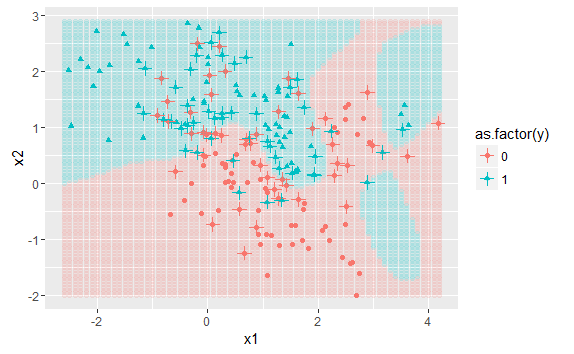

```r
#wygenerujemy siatkę punktów
xgrid=expand.grid(x1=px1,x2=px2) #generating grid points
ygrid=predict(radial.svm,newdata = xgrid) #ygird consisting of predicted Response values
#Wykres z zaznaczonymi wektorami podpierajacymi:
df1<-data.frame("x1"=xgrid$x1, "x2"=xgrid$x2, "y"=ygrid)
p<- ggplot(df, aes(x=x1))+geom_point(aes( y=x2,shape=as.factor(y) ,color=as.factor(y)))
p<- p +   geom_point( data=df1, aes(x=x1, y=x2,  color=as.factor(y)),  shape=19  , alpha=0.1)
p<- p +   geom_point( data=support.vectors, aes(x=x1, y=x2 ,color=as.factor(y) ),  shape=3  ,  size = 3, alpha=1)
p
```

### Wybór najlepszych parametrów dla modelu

```r
require(e1071)
svm_tune <- tune("svm",  data=df, train.x=as.formula("factor(y) ~ ."), kernel="radial", ranges=list(cost=10^(-2:2), gamma=2^(-2:2)))
svm_tune
```

```
Parameter tuning of ‘svm’:

- sampling method: 10-fold cross validation

- best parameters:
 cost gamma
    1     4

- best performance: 0.15
```

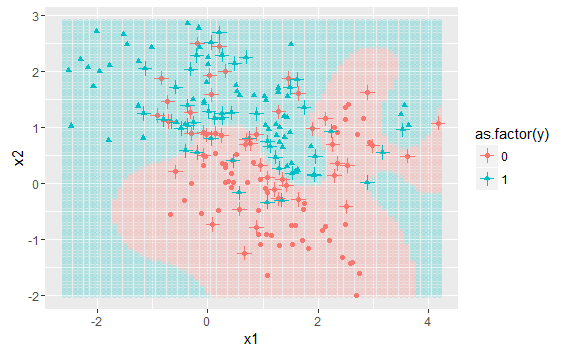

```r
ygrid=predict(svm_tune$best.model,newdata = xgrid) #ygird consisting of predicted Response values
#Wykres z zaznaczonymi wektorami podpierajacymi:
df1<-data.frame("x1"=xgrid$x1, "x2"=xgrid$x2, "y"=ygrid)
p<- ggplot(df, aes(x=x1))+geom_point(aes( y=x2,shape=as.factor(y) ,color=as.factor(y)))
p<- p +   geom_point( data=df1, aes(x=x1, y=x2,  color=as.factor(y)),  shape=19  , alpha=0.1)
p<- p +   geom_point( data=support.vectors, aes(x=x1, y=x2 ,color=as.factor(y) ),  shape=3  ,  size = 3, alpha=1)
p
```